# Project Group - 17

Members: Can Balkose, Zep Van Boxtel, Stan Vos, Julia Michels

Student numbers: 6068383 , 4903684 , 4725603 , 4996569

# Research Objective

*Requires data modeling and quantitative research in Transport, Infrastructure & Logistics*

**Research Question**:

**Effect of COVID on the transportation usage and mode of choice on different regions and demographics in the Netherlands.**

**Objectives**

-To analyze and visualize the impact of the COVID-19 pandemic on transportation usage and mode choice in different regions within the Netherlands.

-To provide insights into how government policies, and public sentiment influenced transportation trends during the pandemic.

-What were the key demographic factors influencing transportation mode choice during the pandemic?

-Understanding how urban and rural cities were affected differently from the pandemic on transportation usage and mode of transportation

-To understand the change of behavior in different demographics on transportation after the pandemic. Coming up with a conclusion on the potential long-term impacts on transportation behavior post-pandemic

# Data Used

```python
import pandas as pd
from scipy.signal import find_peaks
from scipy.signal import argrelextrema
import numpy as np
import matplotlib.pyplot as plt
import seaborn as sns
import plotly.express as px
```

```python
#data of distance covered in regions based on urbanization of region and mode of transport
data_distance_mode_urban= 'data/Distance_covered_on_different_urban_areas.csv'
df_urbanization_mode_urban = pd.read_csv(data_distance_mode_urban)
#filter out the rows where mode of transport is 'combined'
filtered_df_urbanization_mode_urban = df_urbanization_mode_urban[df_urbanization_mode_urban["Mode of Transport"] != 'Combined']
```

```python
#data of usage of public transportation in different demographics
data_usage_of_public_transport= 'data/Usage_of_public_transportation.csv'
df_usage_of_public_transport = pd.read_csv(data_usage_of_public_transport)
```

```python
#the amount of traffix on dutch highway on weekdays and weekends compared to 2019 (2019 = 100)
data_traffic_highways = 'data/CBS Dutch highway traffic.csv'
df_data_traffic_highways = pd.read_csv(data_traffic_highways)
df_data_traffic_highways = df_data_traffic_highways.iloc[:-3]
```

```python
data_2018_2022 = 'data/2018_2022.csv'
df_data_2018_2022 = pd.read_csv(data_2018_2022)
```

```python
# For the data for the Equivalised income groups

filtered_income_df_usage_of_public_transport = df_usage_of_public_transport[df_usage_of_public_transport['Demographic'].str.contains('Equ')]
```

# 1. Introduction

The consequences of the COVID-19 pandemic has influenced almost every facet of the daily lives of people all over the world. Traditionals norms and patterns vanished completely in a two-year period and still left scars for the entire population. One of the sectors in which the scars are still visible is the transportation sector, where the numbers of today still prove that we are still on the way to recovery. This study embarks on a quantitative exploration of the landscape of transportation behavior in the Netherlands before, during and after the COVID-19 pandemic, focussing on the usage and mode preferences across diverse regions and demographic statistics.

# 2. Analysis of affect on transportation mode

The COVID-19 pandemic has had a profound impact on various aspects of our lives, including transportation. In the Netherlands, the pandemic has led to significant changes in travel patterns and the utilization of different transportation modes. The pie charts provided offer valuable insights into these changes, highlighting the impact of COVID-19 on transportation in the Netherlands across different modes. The reason to use pie charts in this visualization was to clearly see the percentages to make better judgement on the changes.

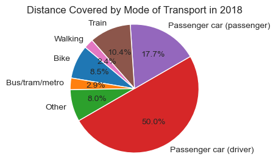

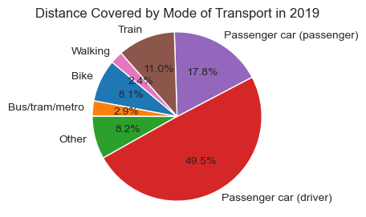

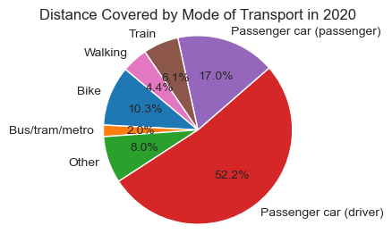

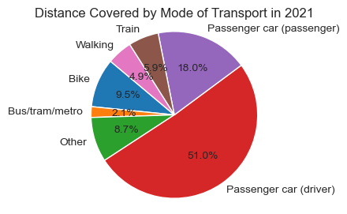

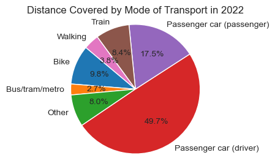

```python
#pie chart to visualise the distance covered by mode of transport per year
years_to_visualize = [2018, 2019, 2020, 2021, 2022]

# Loop through each year
for year in years_to_visualize:
    # Filter the dataframe for the specific year
    df_year = filtered_df_urbanization_mode_urban[filtered_df_urbanization_mode_urban['Year'] == year]

    # Group the data by 'Mode of Transport' and calculate the sum of 'Total Distance (billion km)'
    mode_distance = df_year.groupby('Mode of Transport')['Total Distance (billion km)'].sum()

    # Create a pie chart for the mode-wise distance distribution
    plt.figure(figsize=(3, 3))
    plt.pie(mode_distance, labels=mode_distance.index, autopct='%1.1f%%', startangle=140)
    plt.title(f'Distance Covered by Mode of Transport in {year}')

    plt.axis('equal')
    plt.show()
```

The pie charts illustrate a substantial decrease in public transportation usage during the pandemic. In 2019, public transportation, including buses, trams, and metros, accounted for 13.9% of the total distance traveled in the Netherlands. However, in 2020, it plummeted to a mere 8.1%, indicating a significant shift away from public transport during the pandemic. This decline can be attributed to several factors, including social distancing measures, concerns about virus transmission, and the widespread adoption of remote work and virtual meetings.

While public transportation usage declined, the pie charts reveal a notable increase in cycling and walking during the pandemic. In 2019, cycling accounted for 8.1% of the total distance traveled, while walking comprised 2.4%. In 2020, cycling usage jumped to 10.3%, and walking increased to 4.4%. The increase in distance traveled by walking is very notable as it is almost double compared to what it was pre-covid. This shift towards active transportation modes can be explained by the desire for outdoor activities and the need for physical distancing.

# 3. Analysis of affect on public transportation in different demographics

The animation below shows the usage rate of public transport by different income groups in the Netherlands. Interesting trends can be seen especially in very high income and lower income groups.

```python
# Create a bar chart figure

fig = px.bar(
    filtered_income_df_usage_of_public_transport,
    x="Demographic",
    y="Usage of public transportation (%)",
    color='Demographic',
    animation_frame="Year",
    range_y=[0, 20],
    title="Usage of Public Transportation Over Years",
    labels={"Usage of public transportation (%)": "Usage (%)"},

)
# Update the X-axis ordering to be in descending order of total values

fig.update_xaxes(categoryorder='total descending')

fig.show()
```

[interactive chart not shown]

Prior to the pandemic, public transportation usage among the highest income earners (top 80-100%) in the Netherlands was relatively high, standing at 8.1% in 2018. However, this rate has declined significantly in recent years, falling to 7.6% in 2019, 3.4% in 2020, and 3.1% in 2021. This trend can be attributed to several factors related to the pandemic.

The widespread adoption of work-from-home arrangements during the pandemic reduced the need for commuting, particularly for those in higher-income jobs who were more likely to have the flexibility to work remotely. This shift in work patterns led to a decline in public transportation usage among top earners.

Furthermore, concerns about the risk of infection on public transportation prompted many individuals, particularly those with the financial means, to opt for their own cars as a safer mode of transportation. This increased car usage among top earners further contributed to the decline in public transportation ridership within this income group.

In contrast to the top income group, the lowest income group (bottom 20%) has experienced a rebound in public transportation usage in recent years. While their usage rate dropped to 5.6% in 2020, it has since recovered to 9.5% in 2022. Many individuals in the lowest income group are essential workers who were required to continue working in person throughout the pandemic. This made them more reliant on public transportation to get to and from work, ensuring a continued demand for public transportation services among this income group.

For those in the lowest income group, who may not have their own cars, public transportation remained an essential mode of transportation during the pandemic. The lack of alternative transportation options contributed to the continued reliance on public transportation among this income segment.

Another interesting demographic to look at was age groups. Below animation shows the usage of public transportation by different aga groups in the Netherlands over the years

```python
# For the data for age

filtered_age_df_usage_of_public_transport = df_usage_of_public_transport[df_usage_of_public_transport['Demographic'].str.contains('Age')]
fig = px.bar(
    filtered_age_df_usage_of_public_transport,
    x="Demographic",
    y="Usage of public transportation (%)",
    color='Demographic',
    animation_frame="Year",
    range_y=[0, 20],
    title="Usage of Public Transportation Over Years",
    labels={"Usage of public transportation (%)": "Usage (%)"},

)
# Update the X-axis ordering to be in descending order of total values
fig.update_xaxes(categoryorder='total descending')

fig.show()
```

[interactive chart not shown]

In the aftermath of the initial wave of the pandemic in 2020, public transportation witnessed a decline in ridership as lockdowns and safety concerns prompted individuals to opt for alternative modes of transportation or avoid travel altogether. This trend affected all age groups, creating a common experience of reduced usage of public transportation.

As the recovery in public transportation usage started in 2021, younger individuals, perhaps more adaptable to changing circumstances and less encumbered by health concerns, exhibited a quicker rebound in their use of public transport. By 2022, the data indicated that the younger age groups had returned to their pre-pandemic levels of public transportation usage more compared to the older age groups.

Conversely, older age groups displayed a more cautious and measured reintegration into public transportation systems. Concerns about health risks associated with communal travel, coupled with potential shifts in remote work and lifestyle patterns, contributed to a slower recovery among older individuals.

# 4. Analysis of affect on mobility in different regions

The graph below shows the changes in total distance traveled in different regions (from extremely urbanized to not urbanized) over a time period of 4 years. The difference in urbanization is displayed in different colors.

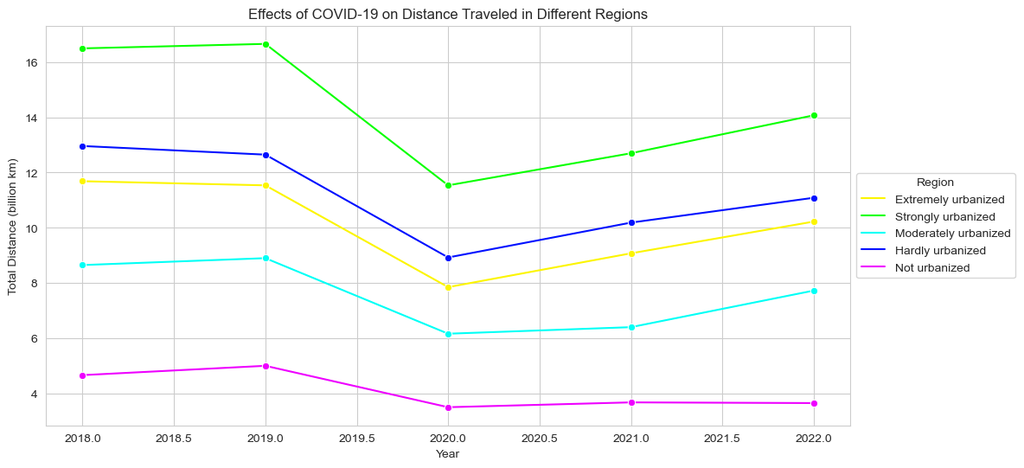

```python
df = pd.DataFrame(df_urbanization_mode_urban)

sns.set_style("whitegrid")

plt.figure(figsize=(12, 6))
sns.lineplot(data=df, x="Year", y="Total Distance (billion km)", hue="Region", marker="o", palette=sns.color_palette("hsv", len(df['Region'].unique())), errorbar=None)

plt.title("Effects of COVID-19 on Distance Traveled in Different Regions")
plt.xlabel("Year")
plt.ylabel("Total Distance (billion km)")
plt.legend(title="Region", loc='center left', bbox_to_anchor=(1, 0.5))
plt.grid(True)
plt.show()
```

The graph above shows the changes in total distance traveled in different regions (from extremely urbanized to not urbanized) over a time period of 4 years. The difference in urbanization is displayed in different colors.

What clearly can be seen is that the pandemic had an influence on the total distance traveled of different demographic groups. It can be seen that strongly urbanized people suffered the most in terms of distance traveled and that people who are don't live in urbanized areas have suffered the least amount due to the pandemic.

People leaving in extremely urbanized areas tend to travel less and that could be explained due to the fact that commuting traffic is very low. This is already shown in some research: people who live in more urbanized areas tend to have a lower commuting distance.

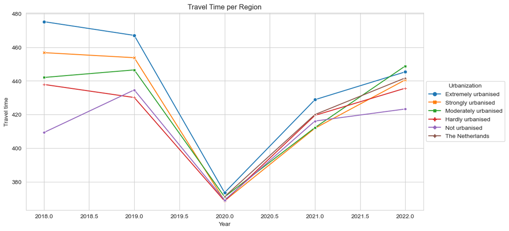

```python
sns.set_style("whitegrid")

plt.figure(figsize=(12, 6))
sns.lineplot(data=df_data_2018_2022, x="Year", y="Travel time", hue="Urbanization", style="Urbanization", markers=True, dashes=False, err_style=None)

plt.title("Travel Time per Region")
plt.xlabel("Year")
plt.ylabel("Travel time")
plt.legend(title="Urbanization", loc='center left', bbox_to_anchor=(1, 0.5))
plt.grid(True)
plt.show()
```

COVID had an impact on the travel time for each region as can be seen in the graph above. For each region, the travel time decreases to its lowest point in 2020. Prior to the pandemic, in 2018, the 'extremely urbanized' region experienced the highest travel time, indicating that the impact on this region was the most significant. From this dip in 2020, the travel time for each region is on the rise again, but the rate of increase is slower than the rate of decrease from 2019 to 2020. In 2022, none of the travel times were as high as they were post-pandemic, except for the 'moderately urbanized' region. Their travel time is even higher than it was before COVID. The difference between the regions has become much smaller than before the pandemic.

# 5. Analysis of Traffic Data over weeks in covid

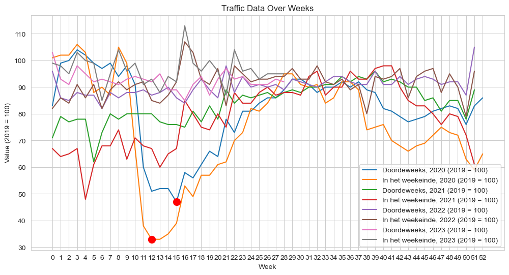

```python
sns.set_style("whitegrid")
plt.figure(figsize=(12, 6))
for column in df_data_traffic_highways.columns[1:]:
    sns.lineplot(x="Week", y=column, data=df_data_traffic_highways, label=column)

plt.legend(loc="upper right")
plt.xlabel("Week")
plt.ylabel("Value (2019 = 100)")
plt.title("Traffic Data Over Weeks")

# Set x-axis labels from 0 to 52 with evenly spaced steps
plt.xticks(range(53), range(53))

for column in df_data_traffic_highways.columns[1:]:
    if "2020" in column:
        lowest_point = df_data_traffic_highways[column].min()
        week_lowest_point = df_data_traffic_highways[df_data_traffic_highways[column] == lowest_point]["Week"].values[0]
        plt.scatter(week_lowest_point, lowest_point, color='red', s=100, zorder=5)

plt.legend()
plt.show()
```

The lowest points in 2020, marked by the red dot, show when traffic was at its lowest. This coincided with the peak of lockdowns when people were staying home, resulting in a significant decrease in travel on Dutch highways.

# 6. Conclusion

In all the graphs above, the impact of COVID-19 on transportation in the Netherlands across various regions and demographics is depicted. The pandemic still has effects on the transportation sector, and the process of recovery is ongoing.

COVID-19 had varying effects on different modes of transportation. Public transport saw a significant decline, while cycling and walking increased. Higher-income earners reduced their usage during the pandemic due to remote work and safety concerns. In contrast, the lowest income group experienced a resurgence in the use of public transportation, relying on it for essential work commutes. The pandemic has reshaped transportation patterns, with urbanization, income levels, and safety concerns playing significant roles in these changes.

Highly urbanized areas experienced the most significant reductions in distance and travel time as a result of the pandemic. With the exception of moderately urbanized regions, other areas have not yet returned to their pre-pandemic average travel times.

Road traffic specifically seemed to recover after the year 2021 compared to other means of transport. This could be an explanation of private transportation being preferred as usual compared to public transportation due to health concerns after the pandemic

# Contribution Statement

**Stan Vos:** Research objectives, introduction, research on the effects of COVID on the total travel distance

**Zep van Boxtel:** Research objectives and research question, research on the effects of COVID on the Dutch highway traffic, data description

**Julia Michels:** Research on the effects of COVID on the travel time, conclusion, collecting data

**Can Balkose:** Analysis of affect on transportation mode, Analysis of affect on public transportation in different demographics, compiling relevant data, creating a data pipeline, coding logic, github

# Data Used

The CBS datasets provide good and comprehensive information on the transportation in the Netherlands. They include data on distance traveled, travel time, and transportation modes, split into regions, transport modes and demographics. These up-to-date and precise datasets of CBS were essential to the answers to the research question and objective and of course for the analysis and visualization of the impact of COVID-19 on transportation behavior in python. The datasets used are:

1. https://opendata.cbs.nl/statline/#/CBS/en/dataset/84713ENG/table?dl=97AAA
2. https://www.cbs.nl/nl-nl/visualisaties/verkeer-en-vervoer/verkeer/hoe-druk-is-het-op-de-nederlandse-rijkswegen-
3. https://opendata.cbs.nl/#/CBS/en/dataset/84687ENG/table